# Telecom Customer Churn — Predictive Modeling & Retention Strategy

Adarsh Shukla

2025

## Business Context

Telecom companies routinely lose 25–30% of their customer base annually. Every churned customer represents lost recurring revenue plus the cost of acquiring a replacement — typically 5–7x more expensive than retention.

Two questions drive this analysis:

1. Which customers are most likely to leave — and how confident is the model?
2. What is the financial case for intervening, and what does intervention cost?

The dataset contains 6,499 customer records across 17 features — contract type, tenure, service configuration, billing method, and churn status.

## Key Results

Before the technical detail, here is what the analysis produced.

**Model performance (Logistic Regression — best model):**

- AUC: 0.8355
- Accuracy at optimized threshold (0.6): 79.57%

**Applied to 500 new customers:**

| Metric | Value |
| --- | --- |
| Customers flagged as churn risk | 74 (14.8%) |
| Monthly revenue at risk | $6,158 |
| Proposed incentive cost | $2,220 ($30 per churner) |
| Net benefit if churners retained | $3,938 |
| ROI on incentive spend | 177% |

**Loyalty program extension (internet customers only):**

| Metric | Value |
| --- | --- |
| Eligible at-risk customers | 74 |
| Cost per customer | $259.72 |
| Net benefit per customer | $1,737.48 |
| Total retained revenue | $147,793 |
| Total net benefit | $128,574 |

## Churn Drivers

| Factor | Direction | Odds Ratio |
| --- | --- | --- |
| Fiber optic internet | Increases churn | 3.03x |
| Month-to-month contract | Increases churn | Reference (highest risk) |
| Electronic check payment | Increases churn | 1.42x |
| Senior citizen | Increases churn | 1.36x |
| Two-year contract | Decreases churn | 0.195x (80% less likely) |
| Tenure (each month) | Decreases churn | 0.938x |
| Online security | Decreases churn | 0.686x |

## Retention Strategy

Three interventions ranked by expected ROI:

**1. Contract conversion campaign** Target month-to-month customers with discounted annual contract offers. It’s the highest-volume segment and the strongest predictor — best place to start.

**2. Early-tenure outreach** Customers in their first 12 months churn at disproportionately high rates. Most early churners have already mentally left before anyone reaches out. Getting ahead of that window is the intervention.

## Data Preparation

#### 1. Load and Inspect Data

```r
load("Model_Building_Data.rda")
str(Model_Building_Data)
```

```
## 'data.frame':    6499 obs. of  17 variables:
##  $ Gender          : Factor w/ 2 levels "Female","Male": 1 2 2 2 1 1 2 1 1 2 ...
##  $ SeniorCitizen   : int  0 0 0 0 0 0 0 0 0 0 ...
##  $ Partner         : Factor w/ 2 levels "No","Yes": 2 1 1 1 1 1 1 1 2 1 ...
##  $ Dependents      : Factor w/ 2 levels "No","Yes": 1 1 1 1 1 1 2 1 1 2 ...
##  $ Tenure          : int  1 34 2 45 2 8 22 10 28 62 ...
##  $ PhoneService    : Factor w/ 2 levels "No","Yes": 1 2 2 1 2 2 2 1 2 2 ...
##  $ MultipleLines   : Factor w/ 3 levels "No","No phone service",..: 2 1 1 2 1 3 3 2 3 1 ...
##  $ InternetService : Factor w/ 3 levels "DSL","Fiber optic",..: 1 1 1 1 2 2 2 1 2 1 ...
##  $ OnlineSecurity  : Factor w/ 3 levels "No","No internet service",..: 1 3 3 3 1 1 1 3 1 3 ...
##  $ DeviceProtection: Factor w/ 3 levels "No","No internet service",..: 1 3 1 3 1 3 1 1 3 1 ...
##  $ StreamingMovies : Factor w/ 3 levels "No","No internet service",..: 1 1 1 1 1 3 1 1 3 1 ...
##  $ Contract        : Factor w/ 3 levels "Month-to-month",..: 1 2 1 2 1 1 1 1 1 2 ...
##  $ PaperlessBilling: Factor w/ 2 levels "No","Yes": 2 1 2 1 2 2 2 1 2 1 ...
##  $ PaymentMethod   : Factor w/ 4 levels "Bank transfer (automatic)",..: 3 4 4 1 3 3 2 4 3 1 ...
##  $ MonthlyCharges  : num  29.9 57 53.9 42.3 70.7 ...
##  $ TotalCharges    : num  29.9 1889.5 108.2 1840.8 151.7 ...
##  $ Status          : chr  "Current" "Current" "Left" "Current" ...
```

```r
summary(Model_Building_Data)
```

```
##     Gender     SeniorCitizen    Partner    Dependents     Tenure
##  Female:3232   Min.   :0.0000   No :3365   No :4551   Min.   : 0.00
##  Male  :3267   1st Qu.:0.0000   Yes:3134   Yes:1948   1st Qu.: 9.00
##                Median :0.0000                         Median :29.00
##                Mean   :0.1611                         Mean   :32.26
##                3rd Qu.:0.0000                         3rd Qu.:55.00
##                Max.   :1.0000                         Max.   :72.00
##
##  PhoneService          MultipleLines     InternetService
##  No : 628     No              :3140   DSL        :2221
##  Yes:5871     No phone service: 628   Fiber optic:2855
##               Yes             :2731   No         :1423
##
##
##
##
##              OnlineSecurity            DeviceProtection
##  No                 :3217   No                 :2849
##  No internet service:1423   No internet service:1423
##  Yes                :1859   Yes                :2227
##
##
##
##
##             StreamingMovies           Contract    PaperlessBilling
##  No                 :2555   Month-to-month:3581   No :2658
##  No internet service:1423   One year      :1352   Yes:3841
##  Yes                :2521   Two year      :1566
##
##
##
##
##                    PaymentMethod  MonthlyCharges    TotalCharges
##  Bank transfer (automatic):1425   Min.   : 18.25   Min.   :  18.8
##  Credit card (automatic)  :1394   1st Qu.: 35.20   1st Qu.: 396.2
##  Electronic check         :2171   Median : 70.35   Median :1389.7
##  Mailed check             :1509   Mean   : 64.66   Mean   :2273.5
##                                   3rd Qu.: 89.85   3rd Qu.:3773.4
##                                   Max.   :118.75   Max.   :8684.8
##                                                    NA's   :11
##     Status
##  Length:6499
##  Class :character
##  Mode  :character
##
##
##
##
```

```r
colSums(is.na(Model_Building_Data))
```

```
##           Gender    SeniorCitizen          Partner       Dependents
##                0                0                0                0
##           Tenure     PhoneService    MultipleLines  InternetService
##                0                0                0                0
##   OnlineSecurity DeviceProtection  StreamingMovies         Contract
##                0                0                0                0
## PaperlessBilling    PaymentMethod   MonthlyCharges     TotalCharges
##                0                0                0               11
##           Status
##                0
```

**Note:** 6,499 records, 17 features. TotalCharges has 11 missing values from blank entries stored as character — handled below.

#### 2. Clean and Type-Convert

```r
# TotalCharges stored as character with blanks — convert and remove NAs
Model_Building_Data$TotalCharges <- as.numeric(as.character(Model_Building_Data$TotalCharges))
Model_Building_Data <- na.omit(Model_Building_Data)

# Convert character columns and SeniorCitizen to factors
Model_Building_Data <- Model_Building_Data %>%
  mutate(across(where(is.character), as.factor),
         SeniorCitizen = as.factor(SeniorCitizen))
```

11 rows removed. Final dataset: 6,488 records, class balance maintained (~73% retained, ~27% churned).

## Exploratory Analysis

#### Churn Distribution

```r
ggplot(Model_Building_Data, aes(Status, fill = Status)) +
  geom_bar() +
  scale_fill_manual(values = c("Current" = "#3B82F6", "Left" = "#EF4444")) +
  labs(title = "Customer Churn Distribution", x = NULL, y = "Count") +
  theme_minimal() +
  theme(legend.position = "none")
```

[figure not shown]

The dataset is imbalanced — ~73% retained, ~27% churned. A naive model that always predicts ‘retained’ would already hit 73% accuracy — which is why threshold tuning matters here.

#### Tenure vs Churn

```r
ggplot(Model_Building_Data, aes(x = Status, y = Tenure, fill = Status)) +
  geom_boxplot() +
  scale_fill_manual(values = c("Current" = "#3B82F6", "Left" = "#EF4444")) +
  labs(title = "Tenure Distribution by Churn Status",
       x = NULL, y = "Tenure (months)") +
  theme_minimal() +
  theme(legend.position = "none")
```

[figure not shown]

Churned customers have median tenure well below retained customers. Month 1–12 is where most of the churn happens.

#### Monthly Charges vs Churn

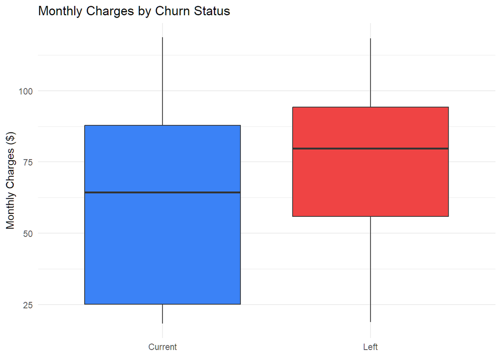

```r
ggplot(Model_Building_Data, aes(x = Status, y = MonthlyCharges, fill = Status)) +
  geom_boxplot() +
  scale_fill_manual(values = c("Current" = "#3B82F6", "Left" = "#EF4444")) +
  labs(title = "Monthly Charges by Churn Status",
       x = NULL, y = "Monthly Charges ($)") +
  theme_minimal() +
  theme(legend.position = "none")
```

Churned customers pay higher monthly charges on average — paying more per month and leaving sooner go together.

#### Contract Type

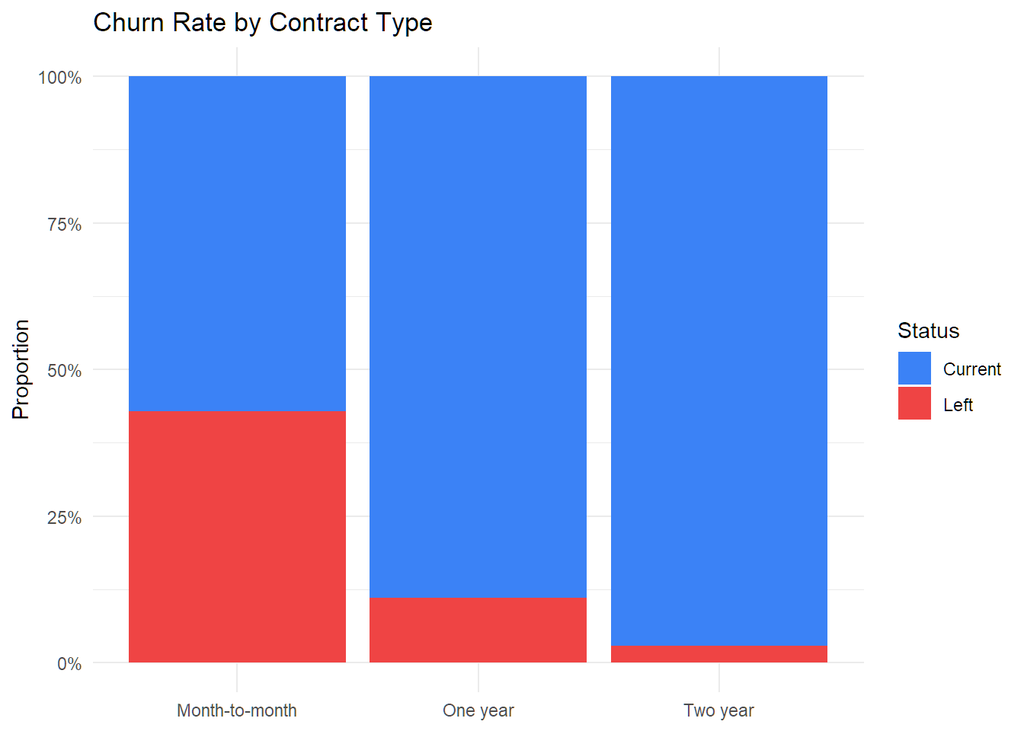

```r
ggplot(Model_Building_Data, aes(x = Contract, fill = Status)) +
  geom_bar(position = "fill") +
  scale_y_continuous(labels = scales::percent) +
  scale_fill_manual(values = c("Current" = "#3B82F6", "Left" = "#EF4444")) +
  labs(title = "Churn Rate by Contract Type",
       x = NULL, y = "Proportion") +
  theme_minimal()
```

Month-to-month customers churn at dramatically higher rates. Two-year contract holders barely churn at all.

#### Internet Service

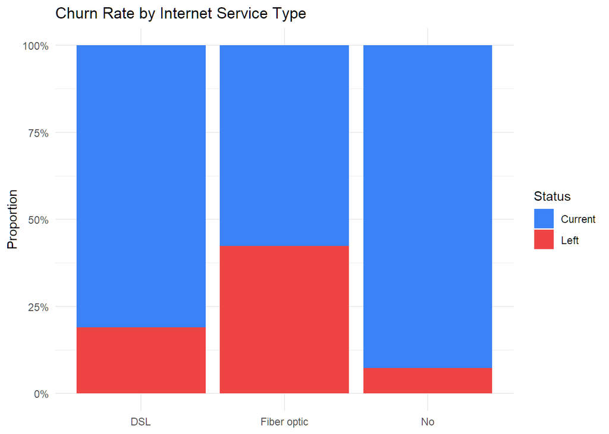

```r
ggplot(Model_Building_Data, aes(x = InternetService, fill = Status)) +
  geom_bar(position = "fill") +
  scale_y_continuous(labels = scales::percent) +
  scale_fill_manual(values = c("Current" = "#3B82F6", "Left" = "#EF4444")) +
  labs(title = "Churn Rate by Internet Service Type",
       x = NULL, y = "Proportion") +
  theme_minimal()
```

Fiber optic customers churn at nearly double the rate of DSL customers — despite paying more. That 3.03x odds ratio is the single largest in the model.

#### Payment Method

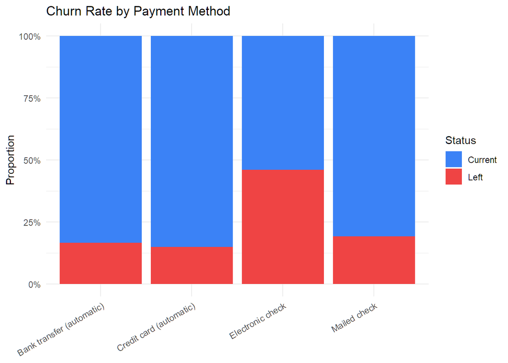

```r
ggplot(Model_Building_Data, aes(x = PaymentMethod, fill = Status)) +
  geom_bar(position = "fill") +
  scale_y_continuous(labels = scales::percent) +
  scale_fill_manual(values = c("Current" = "#3B82F6", "Left" = "#EF4444")) +
  labs(title = "Churn Rate by Payment Method",
       x = NULL, y = "Proportion") +
  theme_minimal() +
  theme(axis.text.x = element_text(angle = 30, hjust = 1))
```

Electronic check users churn at notably higher rates. Customers on auto-pay — bank transfer or credit card — churn at noticeably lower rates.

## Train-Test Split

```r
set.seed(123)
split <- createDataPartition(Model_Building_Data$Status, p = 0.8, list = FALSE)
train_data <- Model_Building_Data[split, ]
test_data  <- Model_Building_Data[-split, ]

prop.table(table(train_data$Status))
```

```
##
##   Current      Left
## 0.7331921 0.2668079
```

```r
prop.table(table(test_data$Status))
```

```
##
##   Current      Left
## 0.7332305 0.2667695
```

80/20 stratified split. Class balance preserved in both subsets (~73% Current / ~27% Left in each).

## Model Building

Five models were built and evaluated on AUC and threshold-optimized accuracy. Each model uses the same train/test split for fair comparison.

### 5.1 Logistic Regression

```r
logit_model_full <- glm(Status ~ ., data = train_data, family = binomial)
summary(logit_model_full)
```

```
##
## Call:
## glm(formula = Status ~ ., family = binomial, data = train_data)
##
## Coefficients: (4 not defined because of singularities)
##                                        Estimate Std. Error z value Pr(>|z|)
## (Intercept)                           2.803e-01  3.089e-01   0.908 0.364074
## GenderMale                            6.911e-03  7.589e-02   0.091 0.927436
## SeniorCitizen1                        3.056e-01  9.779e-02   3.125 0.001779 **
## PartnerYes                            4.134e-03  9.057e-02   0.046 0.963596
## DependentsYes                        -1.849e-01  1.050e-01  -1.762 0.078143 .
## Tenure                               -6.398e-02  7.501e-03  -8.530  < 2e-16 ***
## PhoneServiceYes                      -5.431e-01  2.110e-01  -2.574 0.010060 *
## MultipleLinesNo phone service                NA         NA      NA       NA
## MultipleLinesYes                      2.334e-01  1.013e-01   2.304 0.021234 *
## InternetServiceFiber optic            1.107e+00  2.136e-01   5.184 2.18e-07 ***
## InternetServiceNo                    -8.469e-01  2.714e-01  -3.120 0.001809 **
## OnlineSecurityNo internet service            NA         NA      NA       NA
## OnlineSecurityYes                    -3.775e-01  1.039e-01  -3.634 0.000279 ***
## DeviceProtectionNo internet service          NA         NA      NA       NA
## DeviceProtectionYes                  -4.338e-02  1.028e-01  -0.422 0.672897
## StreamingMoviesNo internet service           NA         NA      NA       NA
## StreamingMoviesYes                    2.853e-01  1.324e-01   2.155 0.031137 *
## ContractOne year                     -7.025e-01  1.256e-01  -5.595 2.21e-08 ***
## ContractTwo year                     -1.633e+00  2.145e-01  -7.610 2.73e-14 ***
## PaperlessBillingYes                   3.021e-01  8.596e-02   3.515 0.000441 ***
## PaymentMethodCredit card (automatic) -1.345e-01  1.332e-01  -1.009 0.312927
## PaymentMethodElectronic check         3.498e-01  1.096e-01   3.192 0.001411 **
## PaymentMethodMailed check            -8.444e-02  1.332e-01  -0.634 0.526108
## MonthlyCharges                       -6.848e-03  7.701e-03  -0.889 0.373836
## TotalCharges                          3.647e-04  8.466e-05   4.308 1.64e-05 ***
## ---
## Signif. codes:  0 '***' 0.001 '**' 0.01 '*' 0.05 '.' 0.1 ' ' 1
##
## (Dispersion parameter for binomial family taken to be 1)
##
##     Null deviance: 6022.2  on 5190  degrees of freedom
## Residual deviance: 4257.1  on 5170  degrees of freedom
## AIC: 4299.1
##
## Number of Fisher Scoring iterations: 6
```

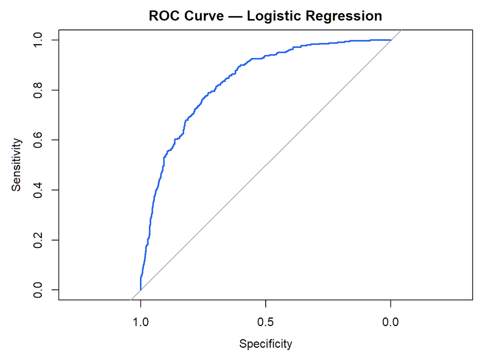

```r
test_probs <- predict(logit_model_full, newdata = test_data, type = "response")

roc_logit <- roc(test_data$Status, test_probs)
plot(roc_logit, col = "#2563EB", lwd = 2,
     main = "ROC Curve — Logistic Regression")
```

```r
auc(roc_logit)
```

```
## Area under the curve: 0.8355
```

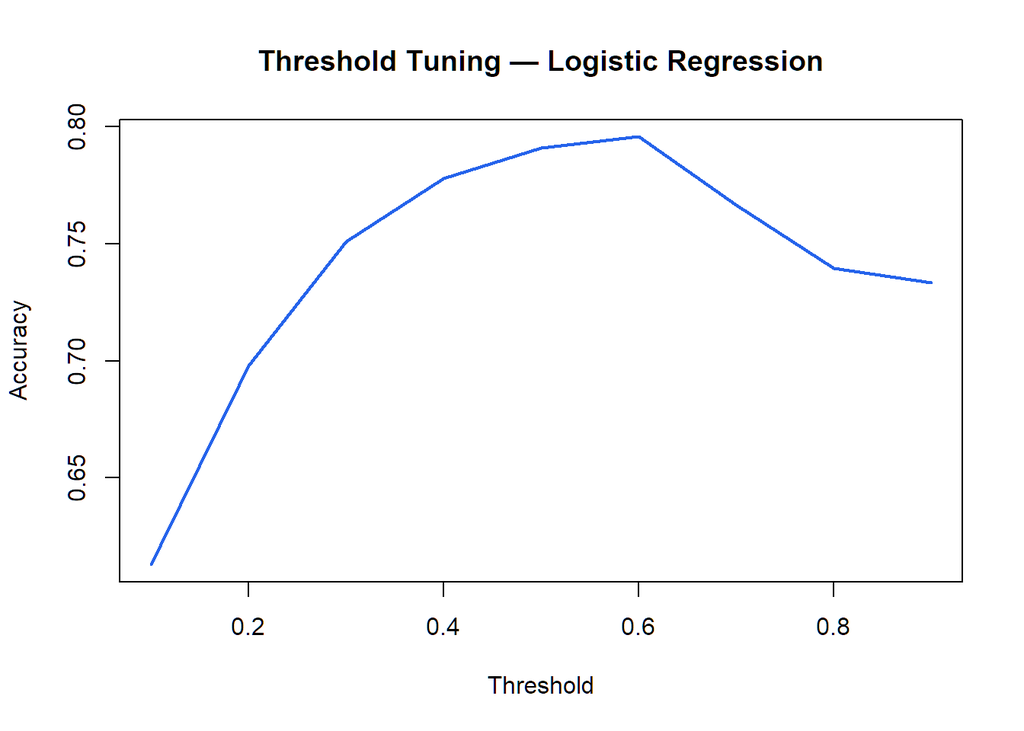

```r
# Threshold tuning
thresholds <- seq(0.1, 0.9, by = 0.1)
accuracy <- sapply(thresholds, function(th) {
  mean(ifelse(test_probs > th, "Left", "Current") == test_data$Status)
})

plot(thresholds, accuracy, type = "l", col = "#2563EB", lwd = 2,
     xlab = "Threshold", ylab = "Accuracy",
     main = "Threshold Tuning — Logistic Regression")
```

```r
best_thresh <- thresholds[which.max(accuracy)]
cat("Best threshold:", best_thresh, "\n")
```

```
## Best threshold: 0.6
```

```r
cat("Best accuracy:", max(accuracy), "\n")
```

```
## Best accuracy: 0.7956823
```

```r
final_preds <- ifelse(test_probs > best_thresh, "Left", "Current")
confusionMatrix(as.factor(final_preds), test_data$Status, positive = "Left")
```

```
## Confusion Matrix and Statistics
##
##           Reference
## Prediction Current Left
##    Current     878  192
##    Left         73  154
##
##                Accuracy : 0.7957
##                  95% CI : (0.7727, 0.8173)
##     No Information Rate : 0.7332
##     P-Value [Acc > NIR] : 1.043e-07
##
##                   Kappa : 0.4136
##
##  Mcnemar's Test P-Value : 4.208e-13
##
##             Sensitivity : 0.4451
##             Specificity : 0.9232
##          Pos Pred Value : 0.6784
##          Neg Pred Value : 0.8206
##              Prevalence : 0.2668
##          Detection Rate : 0.1187
##    Detection Prevalence : 0.1750
##       Balanced Accuracy : 0.6842
##
##        'Positive' Class : Left
##
```

```r
# Odds ratios
odds_ratios <- sort(exp(coef(logit_model_full)), decreasing = TRUE)
odds_ratios
```

```
##           InternetServiceFiber optic        PaymentMethodElectronic check
##                            3.0265409                            1.4187315
##                       SeniorCitizen1                  PaperlessBillingYes
##                            1.3574072                            1.3527023
##                   StreamingMoviesYes                          (Intercept)
##                            1.3301151                            1.3235711
##                     MultipleLinesYes                           GenderMale
##                            1.2628313                            1.0069352
##                           PartnerYes                         TotalCharges
##                            1.0041425                            1.0003648
##                       MonthlyCharges                  DeviceProtectionYes
##                            0.9931751                            0.9575438
##                               Tenure            PaymentMethodMailed check
##                            0.9380215                            0.9190252
## PaymentMethodCredit card (automatic)                        DependentsYes
##                            0.8741912                            0.8312068
##                    OnlineSecurityYes                      PhoneServiceYes
##                            0.6855456                            0.5809705
##                     ContractOne year                    InternetServiceNo
##                            0.4953213                            0.4287562
##                     ContractTwo year
##                            0.1953900
```

AUC: **0.8355** | Best accuracy: **79.57%** at threshold 0.6

Fiber optic (3.03x), electronic check (1.42x), and senior citizen status (1.36x) are the strongest positive churn predictors. Two-year contracts (0.195x) are the strongest retention signal.

### 5.2 Naive Bayes

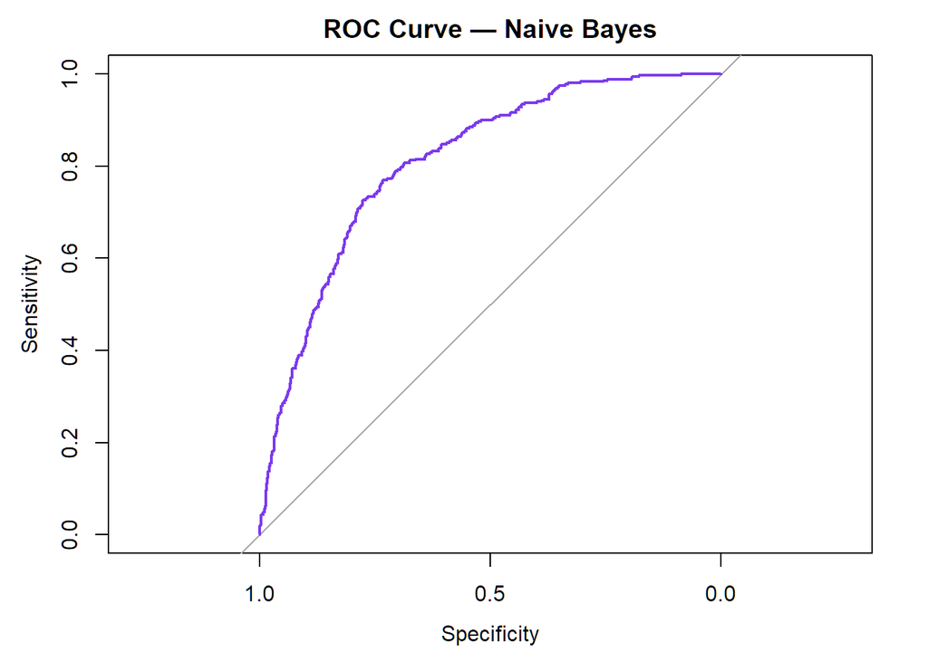

```r
nb_model <- naive_bayes(Status ~ ., data = train_data)
nb_probs <- predict(nb_model, newdata = test_data, type = "prob")[, "Left"]

nb_roc <- roc(test_data$Status, nb_probs)
plot(nb_roc, col = "#7C3AED", lwd = 2,
     main = "ROC Curve — Naive Bayes")
```

```r
auc(nb_roc)
```

```
## Area under the curve: 0.8112
```

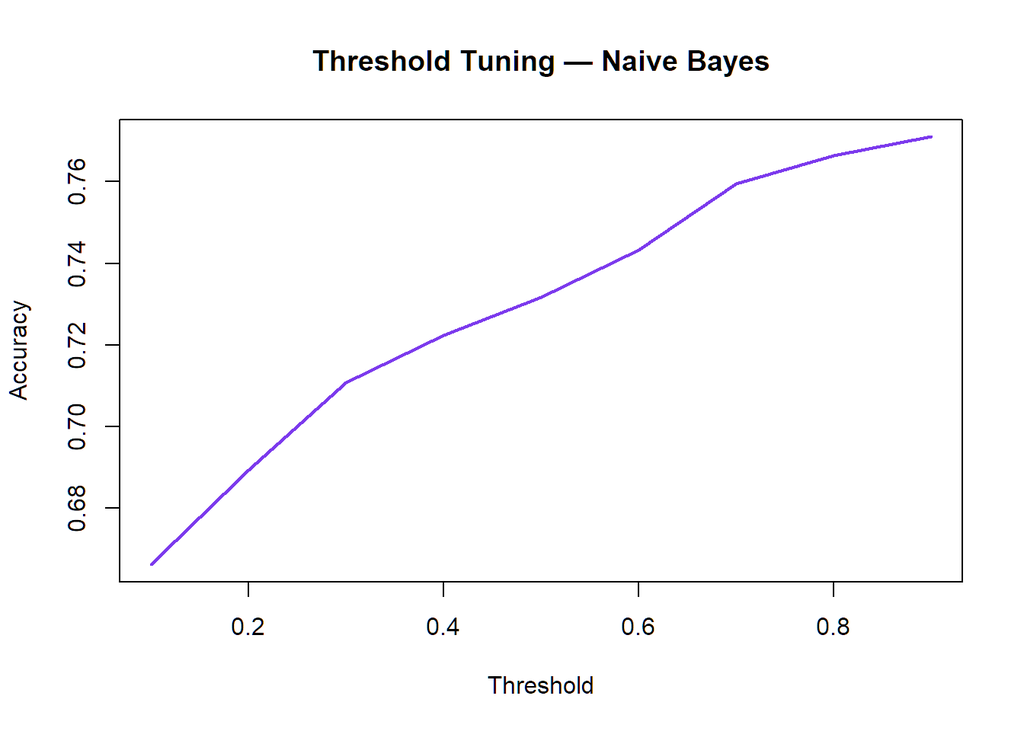

```r
nb_accuracy <- sapply(thresholds, function(th) {
  mean(ifelse(nb_probs > th, "Left", "Current") == test_data$Status)
})

plot(thresholds, nb_accuracy, type = "l", col = "#7C3AED", lwd = 2,
     xlab = "Threshold", ylab = "Accuracy",
     main = "Threshold Tuning — Naive Bayes")
```

```r
nb_best_thresh <- thresholds[which.max(nb_accuracy)]
cat("Best threshold:", nb_best_thresh, "\n")
```

```
## Best threshold: 0.9
```

```r
nb_final_preds <- ifelse(nb_probs > nb_best_thresh, "Left", "Current")
confusionMatrix(as.factor(nb_final_preds), test_data$Status, positive = "Left")
```

```
## Confusion Matrix and Statistics
##
##           Reference
## Prediction Current Left
##    Current     808  154
##    Left        143  192
##
##                Accuracy : 0.771
##                  95% CI : (0.7472, 0.7936)
##     No Information Rate : 0.7332
##     P-Value [Acc > NIR] : 0.001005
##
##                   Kappa : 0.4087
##
##  Mcnemar's Test P-Value : 0.561740
##
##             Sensitivity : 0.5549
##             Specificity : 0.8496
##          Pos Pred Value : 0.5731
##          Neg Pred Value : 0.8399
##              Prevalence : 0.2668
##          Detection Rate : 0.1480
##    Detection Prevalence : 0.2583
##       Balanced Accuracy : 0.7023
##
##        'Positive' Class : Left
##
```

AUC: **0.8112** | Best accuracy: **77.10%** at threshold 0.9

### 5.3 Linear Discriminant Analysis (LDA)

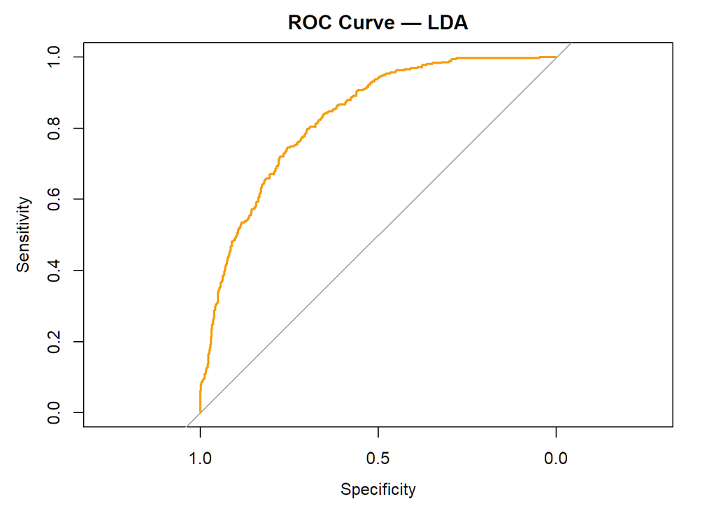

```r
lda_model <- lda(Status ~ ., data = train_data)
lda_pred  <- predict(lda_model, newdata = test_data)
lda_probs <- lda_pred$posterior[, "Left"]

lda_roc <- roc(test_data$Status, lda_probs)
plot(lda_roc, col = "#F59E0B", lwd = 2,
     main = "ROC Curve — LDA")
```

```r
auc(lda_roc)
```

```
## Area under the curve: 0.8289
```

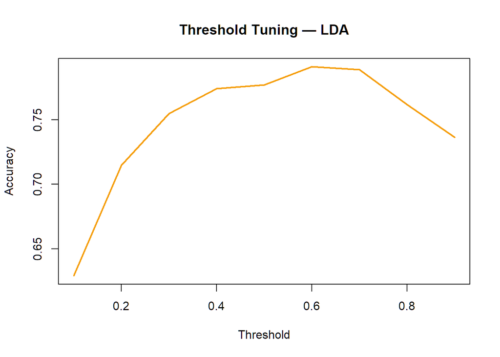

```r
lda_accuracy <- sapply(thresholds, function(th) {
  mean(ifelse(lda_probs > th, "Left", "Current") == test_data$Status)
})

plot(thresholds, lda_accuracy, type = "l", col = "#F59E0B", lwd = 2,
     xlab = "Threshold", ylab = "Accuracy",
     main = "Threshold Tuning — LDA")
```

```r
lda_best_thresh <- thresholds[which.max(lda_accuracy)]
cat("Best threshold:", lda_best_thresh, "\n")
```

```
## Best threshold: 0.6
```

```r
lda_final_preds <- ifelse(lda_probs > lda_best_thresh, "Left", "Current")
confusionMatrix(as.factor(lda_final_preds), test_data$Status, positive = "Left")
```

```
## Confusion Matrix and Statistics
##
##           Reference
## Prediction Current Left
##    Current     853  173
##    Left         98  173
##
##                Accuracy : 0.7911
##                  95% CI : (0.7679, 0.8129)
##     No Information Rate : 0.7332
##     P-Value [Acc > NIR] : 8.212e-07
##
##                   Kappa : 0.4263
##
##  Mcnemar's Test P-Value : 6.951e-06
##
##             Sensitivity : 0.5000
##             Specificity : 0.8970
##          Pos Pred Value : 0.6384
##          Neg Pred Value : 0.8314
##              Prevalence : 0.2668
##          Detection Rate : 0.1334
##    Detection Prevalence : 0.2089
##       Balanced Accuracy : 0.6985
##
##        'Positive' Class : Left
##
```

AUC: **0.8289** | Best accuracy: **79.11%** at threshold 0.6

### 5.4 Quadratic Discriminant Analysis (QDA)

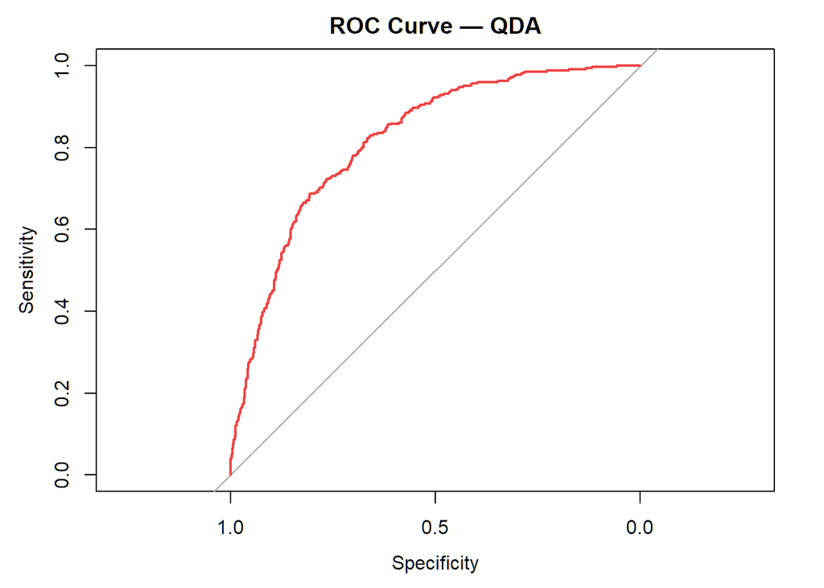

```r
# Collapse "No internet/phone service" levels for QDA compatibility
qda_train <- train_data
qda_test  <- test_data

cols_to_clean <- c("MultipleLines", "OnlineSecurity", "DeviceProtection", "StreamingMovies")
for (col in cols_to_clean) {
  for (df in c("qda_train", "qda_test")) {
    temp <- get(df)
    temp[[col]] <- as.character(temp[[col]])
    temp[[col]][temp[[col]] %in% c("No internet service", "No phone service")] <- "No"
    temp[[col]] <- as.factor(temp[[col]])
    assign(df, temp)
  }
}

qda_model <- qda(Status ~ ., data = qda_train)
qda_pred  <- predict(qda_model, newdata = qda_test)
qda_probs <- qda_pred$posterior[, "Left"]

qda_roc <- roc(qda_test$Status, qda_probs)
plot(qda_roc, col = "#EF4444", lwd = 2,
     main = "ROC Curve — QDA")
```

```r
auc(qda_roc)
```

```
## Area under the curve: 0.818
```

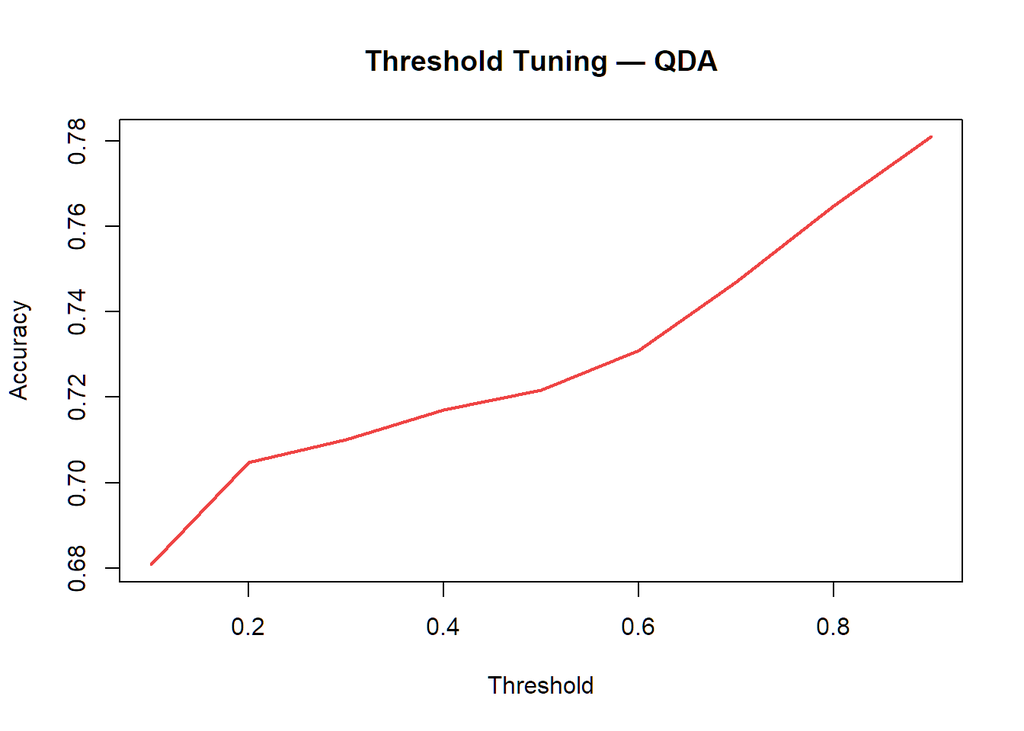

```r
qda_accuracy <- sapply(thresholds, function(th) {
  mean(ifelse(qda_probs > th, "Left", "Current") == qda_test$Status)
})

plot(thresholds, qda_accuracy, type = "l", col = "#EF4444", lwd = 2,
     xlab = "Threshold", ylab = "Accuracy",
     main = "Threshold Tuning — QDA")
```

```r
qda_best_thresh <- thresholds[which.max(qda_accuracy)]
cat("Best threshold:", qda_best_thresh, "\n")
```

```
## Best threshold: 0.9
```

```r
qda_final_preds <- ifelse(qda_probs > qda_best_thresh, "Left", "Current")
confusionMatrix(as.factor(qda_final_preds), qda_test$Status, positive = "Left")
```

```
## Confusion Matrix and Statistics
##
##           Reference
## Prediction Current Left
##    Current     792  125
##    Left        159  221
##
##                Accuracy : 0.781
##                  95% CI : (0.7575, 0.8033)
##     No Information Rate : 0.7332
##     P-Value [Acc > NIR] : 4.133e-05
##
##                   Kappa : 0.4572
##
##  Mcnemar's Test P-Value : 0.05021
##
##             Sensitivity : 0.6387
##             Specificity : 0.8328
##          Pos Pred Value : 0.5816
##          Neg Pred Value : 0.8637
##              Prevalence : 0.2668
##          Detection Rate : 0.1704
##    Detection Prevalence : 0.2930
##       Balanced Accuracy : 0.7358
##
##        'Positive' Class : Left
##
```

AUC: **0.8180** | Best accuracy: **78.10%** at threshold 0.9

### 5.5 Decision Tree (Pruned)

```r
tree_model <- rpart(Status ~ ., data = train_data, method = "class", cp = 0.001)
printcp(tree_model)
```

```
##
## Classification tree:
## rpart(formula = Status ~ ., data = train_data, method = "class",
##     cp = 0.001)
##
## Variables actually used in tree construction:
##  [1] Contract         Dependents       DeviceProtection Gender
##  [5] InternetService  MonthlyCharges   MultipleLines    OnlineSecurity
##  [9] PaperlessBilling Partner          PaymentMethod    PhoneService
## [13] SeniorCitizen    StreamingMovies  Tenure           TotalCharges
##
## Root node error: 1385/5191 = 0.26681
##
## n= 5191
##
##           CP nsplit rel error  xerror     xstd
## 1  0.0707581      0   1.00000 1.00000 0.023008
## 2  0.0101083      3   0.77906 0.77906 0.021109
## 3  0.0093863      5   0.75884 0.78700 0.021188
## 4  0.0086643      7   0.74007 0.78339 0.021152
## 5  0.0046931      8   0.73141 0.77256 0.021043
## 6  0.0036101     10   0.72202 0.77690 0.021087
## 7  0.0032491     13   0.71119 0.79278 0.021245
## 8  0.0028881     15   0.70469 0.79495 0.021266
## 9  0.0025993     22   0.67942 0.80144 0.021329
## 10 0.0024067     30   0.65415 0.80289 0.021343
## 11 0.0021661     34   0.64116 0.80722 0.021385
## 12 0.0019254     37   0.63466 0.80794 0.021392
## 13 0.0018051     43   0.62310 0.80866 0.021399
## 14 0.0016245     45   0.61949 0.81155 0.021426
## 15 0.0014440     50   0.61083 0.81155 0.021426
## 16 0.0012996     65   0.58845 0.81155 0.021426
## 17 0.0012635     73   0.57762 0.81805 0.021488
## 18 0.0010830     81   0.56751 0.81444 0.021454
## 19 0.0010000     99   0.54801 0.81516 0.021461
```

```r
opt_cp <- tree_model$cptable[which.min(tree_model$cptable[, "xerror"]), "CP"]
cat("Optimal cp:", opt_cp, "\n")
```

```
## Optimal cp: 0.004693141
```

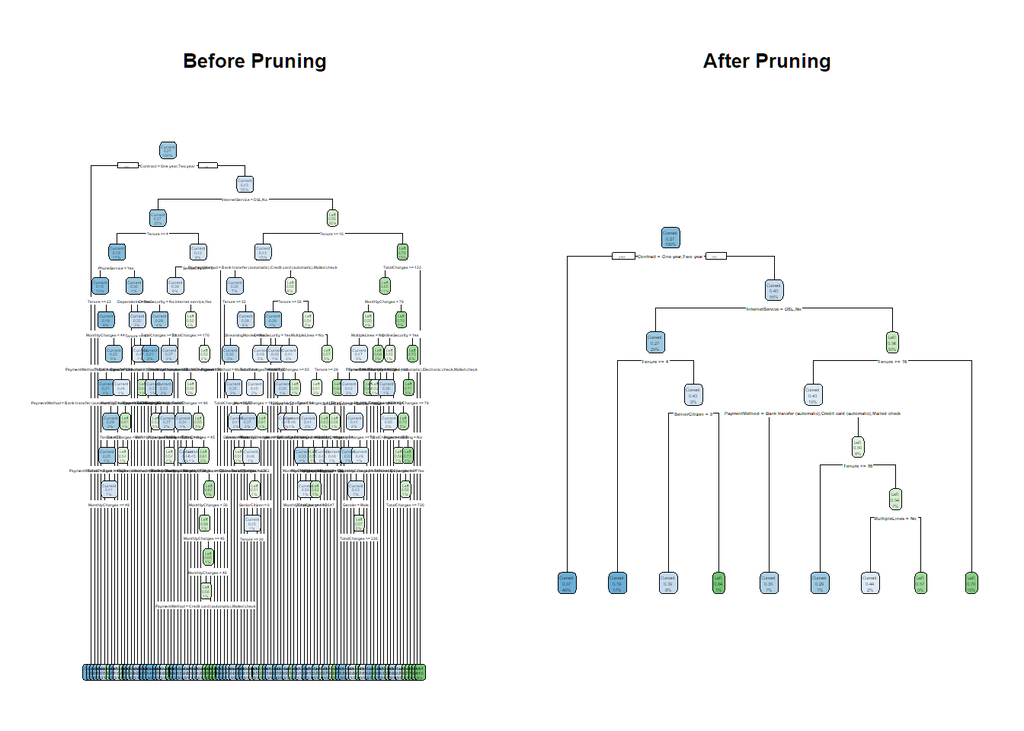

```r
pruned_tree <- prune(tree_model, cp = opt_cp)

par(mfrow = c(1, 2))
rpart.plot(tree_model,  main = "Before Pruning", extra = 106)
rpart.plot(pruned_tree, main = "After Pruning",  extra = 106)
```

```r
par(mfrow = c(1, 1))
```

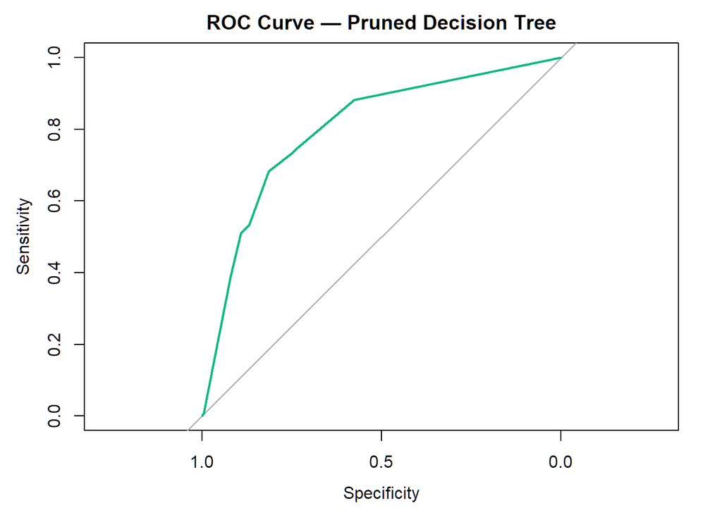

```r
tree_probs <- predict(pruned_tree, newdata = test_data, type = "prob")[, "Left"]

tree_roc <- roc(test_data$Status, tree_probs)
plot(tree_roc, col = "#10B981", lwd = 2,
     main = "ROC Curve — Pruned Decision Tree")
```

```r
auc(tree_roc)
```

```
## Area under the curve: 0.8006
```

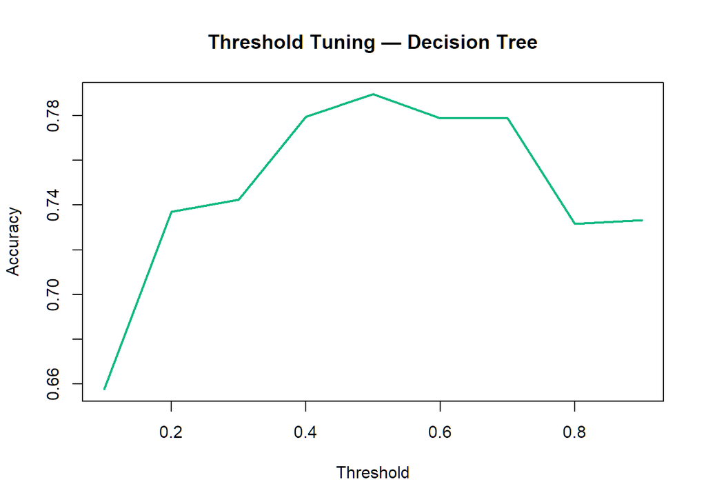

```r
tree_accuracy <- sapply(thresholds, function(th) {
  mean(ifelse(tree_probs > th, "Left", "Current") == test_data$Status)
})

plot(thresholds, tree_accuracy, type = "l", col = "#10B981", lwd = 2,
     xlab = "Threshold", ylab = "Accuracy",
     main = "Threshold Tuning — Decision Tree")
```

```r
tree_best_thresh <- thresholds[which.max(tree_accuracy)]
cat("Best threshold:", tree_best_thresh, "\n")
```

```
## Best threshold: 0.5
```

```r
tree_final_preds <- ifelse(tree_probs > tree_best_thresh, "Left", "Current")
confusionMatrix(as.factor(tree_final_preds), test_data$Status, positive = "Left")
```

```
## Confusion Matrix and Statistics
##
##           Reference
## Prediction Current Left
##    Current     848  170
##    Left        103  176
##
##                Accuracy : 0.7895
##                  95% CI : (0.7663, 0.8114)
##     No Information Rate : 0.7332
##     P-Value [Acc > NIR] : 1.576e-06
##
##                   Kappa : 0.4266
##
##  Mcnemar's Test P-Value : 6.483e-05
##
##             Sensitivity : 0.5087
##             Specificity : 0.8917
##          Pos Pred Value : 0.6308
##          Neg Pred Value : 0.8330
##              Prevalence : 0.2668
##          Detection Rate : 0.1357
##    Detection Prevalence : 0.2151
##       Balanced Accuracy : 0.7002
##
##        'Positive' Class : Left
##
```

AUC: **0.8006** | Best accuracy: **78.95%** at threshold 0.5

Pruning reduced the tree from a complex overfit structure to a clean, interpretable model using Contract, InternetService, Tenure, and PaymentMethod as the primary splits.

## Model Comparison

```r
auc_logit <- auc(roc(test_data$Status, test_probs))
auc_nb    <- auc(roc(test_data$Status, nb_probs))
auc_lda   <- auc(roc(test_data$Status, lda_probs))
auc_qda   <- auc(roc(qda_test$Status, qda_probs))
auc_tree  <- auc(roc(test_data$Status, tree_probs))

acc_logit <- max(sapply(thresholds, function(th) mean(ifelse(test_probs  > th, "Left", "Current") == test_data$Status)))
acc_nb    <- max(sapply(thresholds, function(th) mean(ifelse(nb_probs    > th, "Left", "Current") == test_data$Status)))
acc_lda   <- max(sapply(thresholds, function(th) mean(ifelse(lda_probs   > th, "Left", "Current") == test_data$Status)))
acc_qda   <- max(sapply(thresholds, function(th) mean(ifelse(qda_probs   > th, "Left", "Current") == qda_test$Status)))
acc_tree  <- max(sapply(thresholds, function(th) mean(ifelse(tree_probs  > th, "Left", "Current") == test_data$Status)))

comparison <- data.frame(
  Model         = c("Logistic Regression", "LDA", "QDA", "Decision Tree", "Naive Bayes"),
  AUC           = round(c(auc_logit, auc_lda, auc_qda, auc_tree, auc_nb), 4),
  Best_Accuracy = round(c(acc_logit, acc_lda, acc_qda, acc_tree, acc_nb), 4),
  Best_Threshold = c(0.6, 0.6, 0.9, 0.5, 0.9)
)

knitr::kable(comparison,
             caption = "Model Comparison — AUC and Threshold-Optimized Accuracy",
             col.names = c("Model", "AUC", "Best Accuracy", "Best Threshold"))
```

Model Comparison — AUC and Threshold-Optimized Accuracy

| Model | AUC | Best Accuracy | Best Threshold |
| --- | --- | --- | --- |
| Logistic Regression | 0.8355 | 0.7957 | 0.6 |
| LDA | 0.8289 | 0.7911 | 0.6 |
| QDA | 0.8180 | 0.7810 | 0.9 |
| Decision Tree | 0.8006 | 0.7895 | 0.5 |
| Naive Bayes | 0.8112 | 0.7710 | 0.9 |

**Logistic regression is the recommended model.** It leads on both AUC and accuracy, its coefficients read directly as odds ratios, which gives a retention team something concrete to act on.

## Business Application

The logistic regression model was applied to a held-out implementation dataset of 500 customers to simulate real deployment.

#### Load and Prepare Implementation Data

```r
load("Implementation_Data.rda")

Implementation_Data <- Implementation_Data %>%
  mutate(across(where(is.character), as.factor),
         SeniorCitizen = as.factor(SeniorCitizen))

Implementation_Data$TotalCharges <- as.numeric(as.character(Implementation_Data$TotalCharges))
Implementation_Data <- na.omit(Implementation_Data)
```

#### Score Customers

```r
impl_probs <- predict(logit_model_full, newdata = Implementation_Data, type = "response")
impl_preds <- ifelse(impl_probs > best_thresh, "Left", "Current")

Implementation_Data$PredictedStatus    <- impl_preds
Implementation_Data$ChurnProbability   <- round(impl_probs, 4)
```

#### Revenue at Risk

```r
num_churn_risk  <- sum(Implementation_Data$PredictedStatus == "Left")
revenue_at_risk <- sum(Implementation_Data$MonthlyCharges[Implementation_Data$PredictedStatus == "Left"])

cat("Customers flagged as churn risk:", num_churn_risk, "\n")
```

```
## Customers flagged as churn risk: 74
```

```r
cat("Monthly revenue at risk: $", round(revenue_at_risk, 2), "\n")
```

```
## Monthly revenue at risk: $ 6158.05
```

#### Incentive Simulation

```r
discount_per_month <- 10
discount_months    <- 3
cost_per_churner   <- discount_per_month * discount_months

total_incentive_cost <- num_churn_risk * cost_per_churner
net_benefit          <- revenue_at_risk - total_incentive_cost
roi                  <- (net_benefit / total_incentive_cost) * 100

cat("Incentive cost per customer: $", cost_per_churner, "\n")
```

```
## Incentive cost per customer: $ 30
```

```r
cat("Total incentive spend: $", total_incentive_cost, "\n")
```

```
## Total incentive spend: $ 2220
```

```r
cat("Revenue retained if successful: $", round(revenue_at_risk, 2), "\n")
```

```
## Revenue retained if successful: $ 6158.05
```

```r
cat("Net benefit: $", round(net_benefit, 2), "\n")
```

```
## Net benefit: $ 3938.05
```

```r
cat("ROI on incentive spend:", round(roi, 1), "%\n")
```

```
## ROI on incentive spend: 177.4 %
```

#### Loyalty Program (Internet Customers)

```r
churn_internet <- Implementation_Data %>%
  filter(PredictedStatus == "Left", InternetService != "No")

avg_monthly_bill    <- mean(churn_internet$MonthlyCharges)
discount_24_months  <- 0.10 * avg_monthly_bill * 24
addon_cost          <- 5 * 12
cost_per_customer   <- discount_24_months + addon_cost
retained_per_customer <- avg_monthly_bill * 24
benefit_per_customer  <- retained_per_customer - cost_per_customer

n_eligible            <- nrow(churn_internet)
total_program_cost    <- cost_per_customer * n_eligible
total_retained        <- retained_per_customer * n_eligible
total_net_benefit     <- benefit_per_customer * n_eligible

cat("Eligible customers:", n_eligible, "\n")
```

```
## Eligible customers: 74
```

```r
cat("Avg monthly bill: $", round(avg_monthly_bill, 2), "\n")
```

```
## Avg monthly bill: $ 83.22
```

```r
cat("Cost per customer: $", round(cost_per_customer, 2), "\n")
```

```
## Cost per customer: $ 259.72
```

```r
cat("Net benefit per customer: $", round(benefit_per_customer, 2), "\n")
```

```
## Net benefit per customer: $ 1737.48
```

```r
cat("Total program cost: $", round(total_program_cost, 2), "\n")
```

```
## Total program cost: $ 19219.32
```

```r
cat("Total retained revenue: $", round(total_retained, 2), "\n")
```

```
## Total retained revenue: $ 147793.2
```

```r
cat("Total net benefit: $", round(total_net_benefit, 2), "\n")
```

```
## Total net benefit: $ 128573.9
```

## Summary

**Best model:** Logistic Regression — AUC 0.8355, accuracy 79.57% at threshold 0.6

**Top churn drivers:** - Fiber optic internet (3.03x more likely to churn vs DSL) - Month-to-month contract (reference group — highest risk) - Electronic check payment (1.42x) - Two-year contract (0.195x — strongest retention signal)

**Financial case for action (500 customers):**

| Intervention | Cost | Revenue Protected | Net Benefit |
| --- | --- | --- | --- |
| Short incentive ($30/churner) | $2,220 | $6,158 | $3,938 |
| Loyalty program (internet users) | $19,219 | $147,793 | $128,574 |

Any CRM that takes a probability score can use this directly — flag customers above 0.6, trigger the outreach. The short incentive returns $1.77 for every dollar spent. The loyalty program returns $6.69.